# Mietek_Gerard_5_projekt1.html

Gerard Miętek

2024-11-24

Wgrywanie odpowiednich bibliotek

```r
library('sf')
library('dbscan')
library('glue')
```

Wgrywanie plików .shp

```r
punkty = st_read( "punkty_zmienione.shp" )
osiedla = st_read( "osiedla.shp")
```

Wykres podglądowy

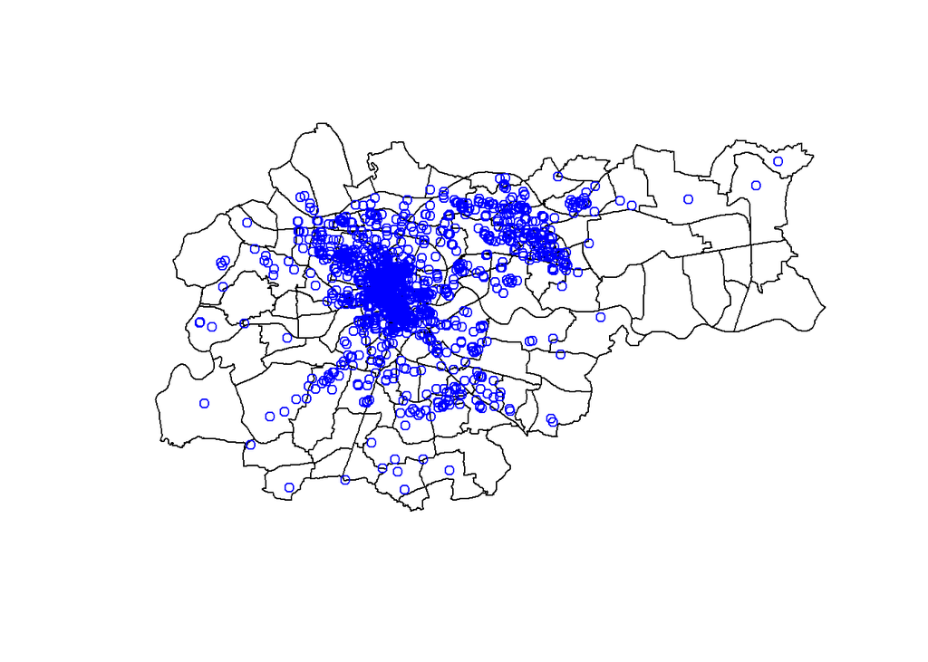

```r
plot( osiedla$geometry)
plot( punkty$geometry, add = TRUE, pch = 1, col = "blue")
```

```r
ramka = data.frame( punkty$POINT_X, punkty$POINT_Y)
```

*ALGORYTM DBSCAN*  
Ustalam pewne odległości (eps) oraz minimalne ilości punktów (minPts), na których sprawdzam i wizualizuję działanie algorytmu dbscan. W tym celu iteruję po wszystkich parach eps-minPts i tworzę mapy, uwzględniając powstałe klastry–>

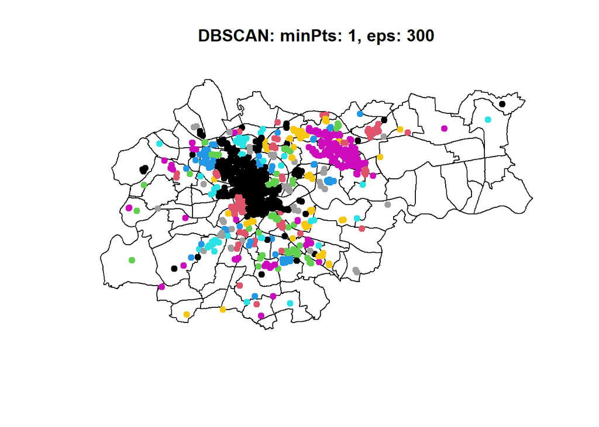

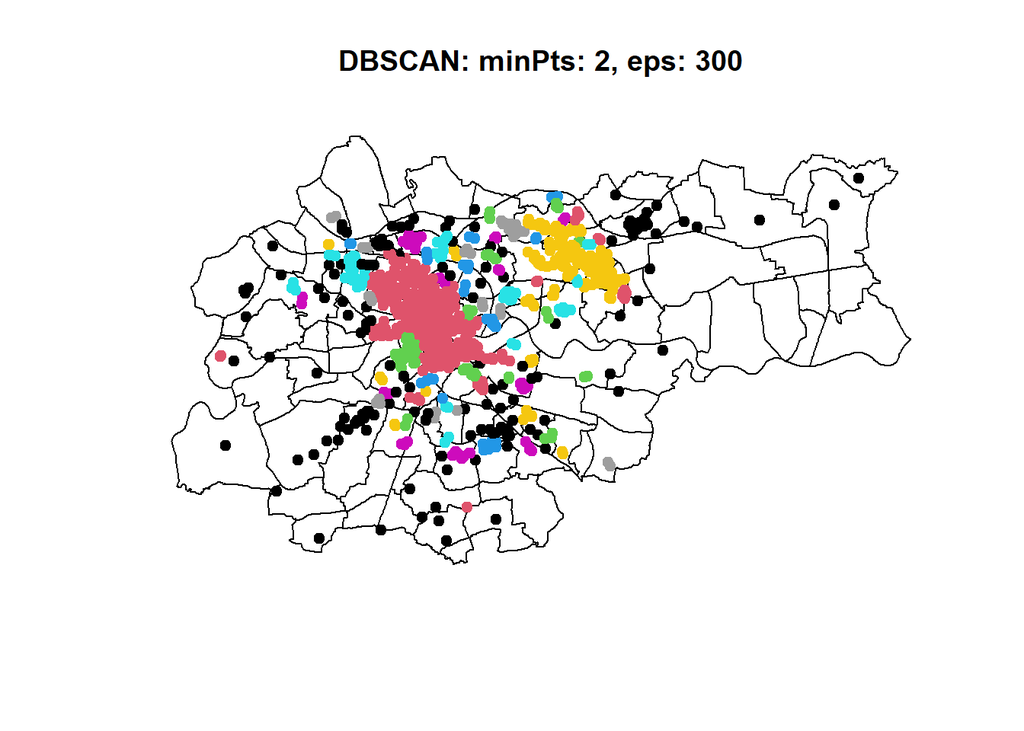

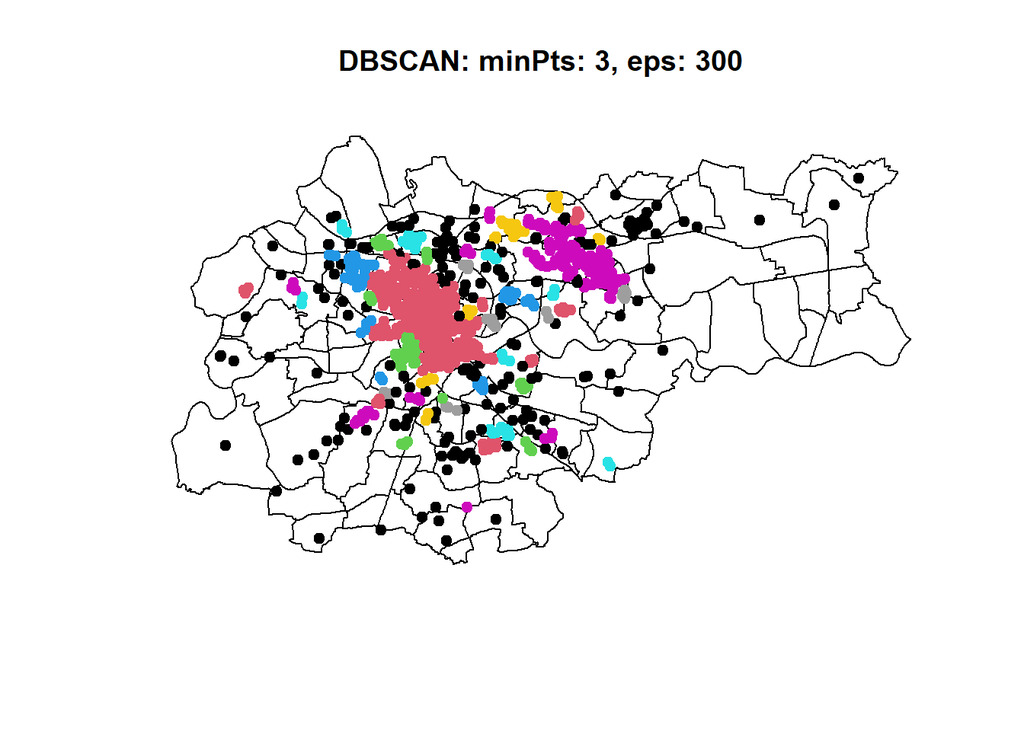

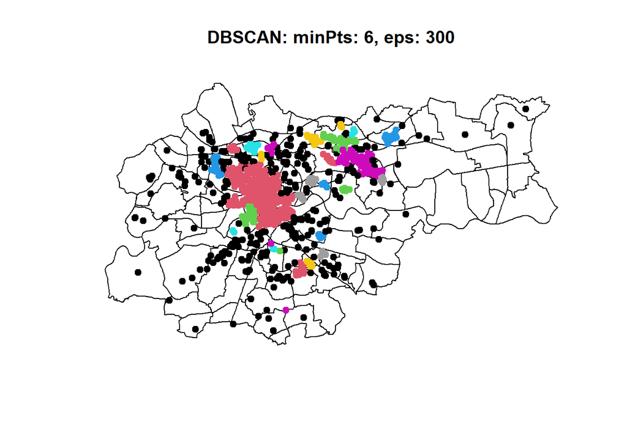

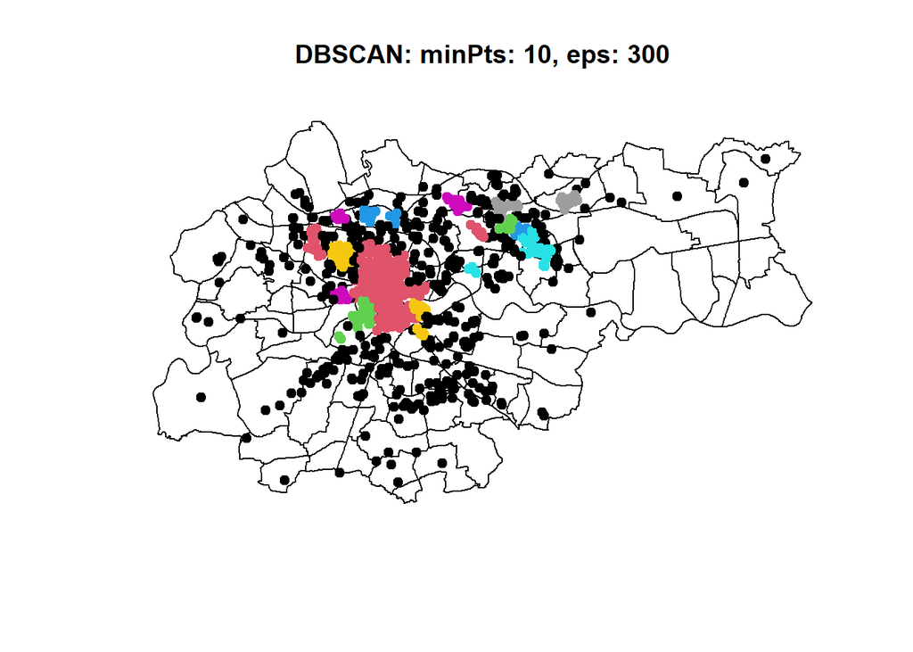

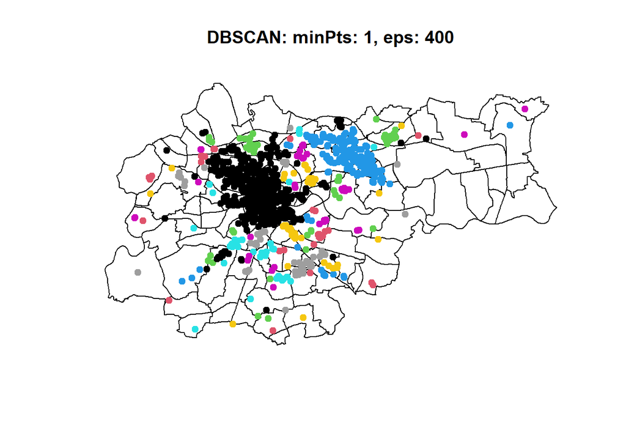

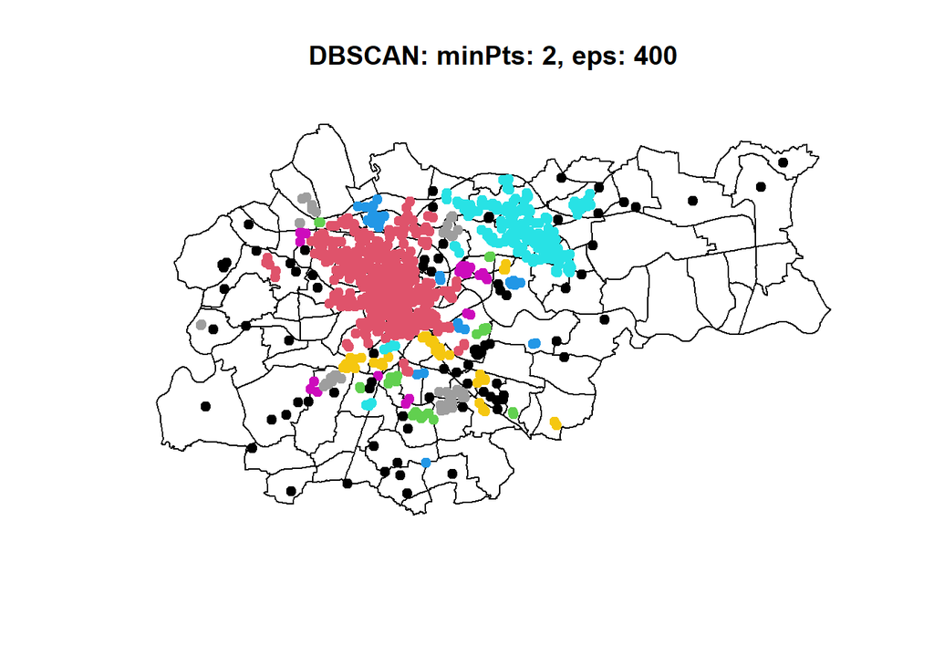

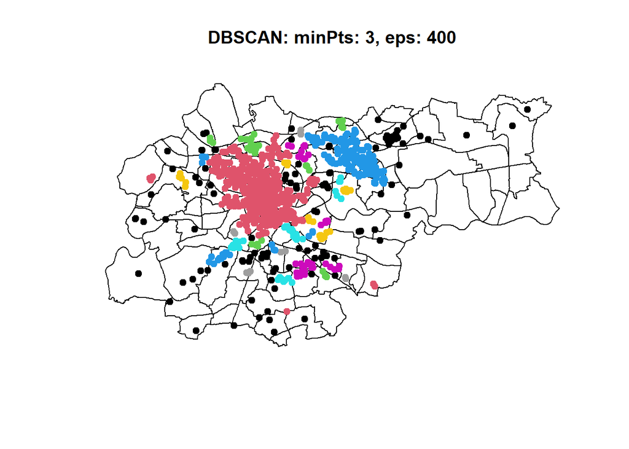

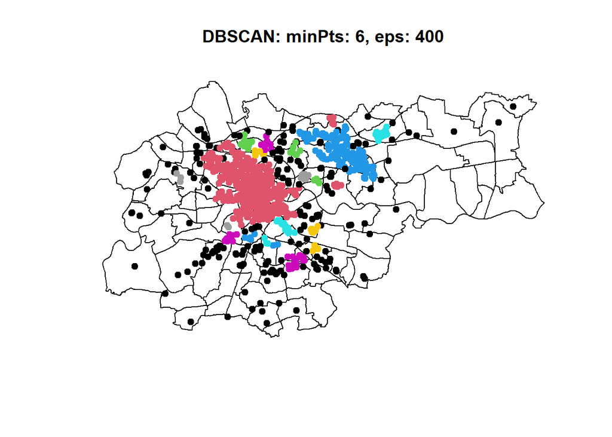

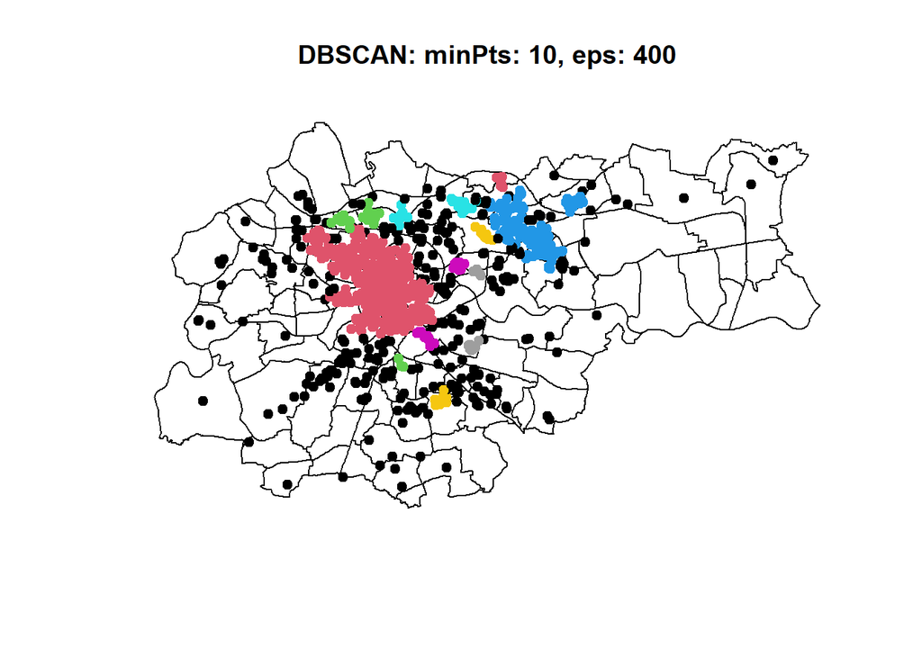

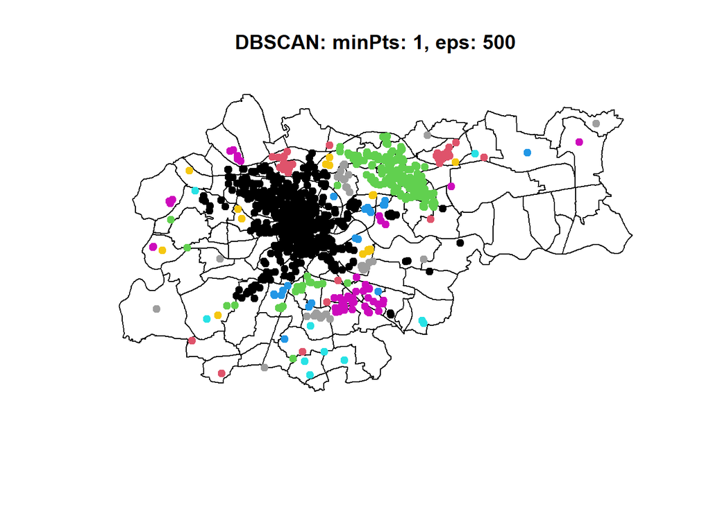

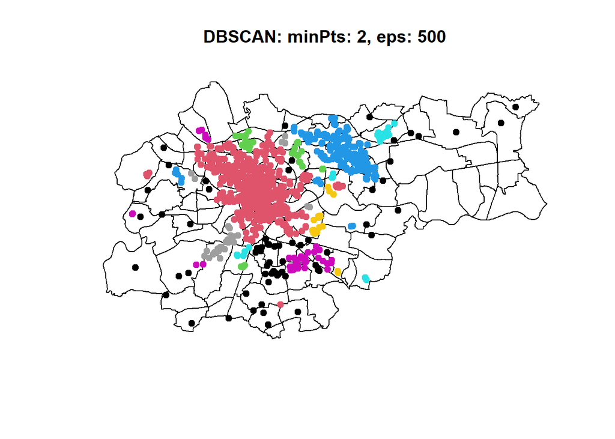

[3 more figures not shown]

```r
eps = c( 300, 400, 500 )
min_pts = c(  1, 2, 3,  6, 10 )

for (e in eps) {
  for (p in min_pts) {
    dbx = dbscan( ramka, minPts = p, eps = e)
    plot( osiedla$geometry)
    plot( punkty$geometry, add = TRUE, pch = 19, col = factor( dbx$cluster ))
    title( main = glue("DBSCAN: minPts: {p}, eps: {e}"))
  }
}
```

##Jedna rzecz rzuca się w oczy w przypadku wszystkich odległości eps. Im większa jest minimalna ilość punktów, tym mniej pojedynczych i porozrzucanych po całym Krakowie mamy klastrów. Co więcej, istnieją pewne kombinacje parametrów, które zupełnie nie przypominają sklasteryzowanego zbioru (jak na przykład minPts 10, eps 300) oraz takie, które dają dość satysfakcjonujący wynik (minPts 2, eps 500 ). Ponadto, zwiększenie zasięgu generalnie zwiększa ogólny rozmiar klastrów, najlepej to widać gdy porównamy rozmiar czerwonego klastra w centrum Krakowa w wizualizacjach dla najmniejszej i największej wartości eps ( 300 oraz 500 )

*ALGORYTM HDBSCAN*  
Najważniejsze różnice pomiędzy algorytmami dbscan i hdbscan:

- dbscan wymaga ręcznego ustawienia promienia eps, podczas gdy hdbscan sam dostosowuje się do różnych gęstości
- hdbscan tworzy hierarchiczną strukturę klastrów i pozwala wybrać najbardziej stabilne.
- dbscan ma dość sztywne reguły jeżeli chodzi o klasyfikachę szumu, a hdbscan identyfikuje go bardziej elastycznie

**Dokonuję podobnej iteracji jak w przypadku dbscan:**

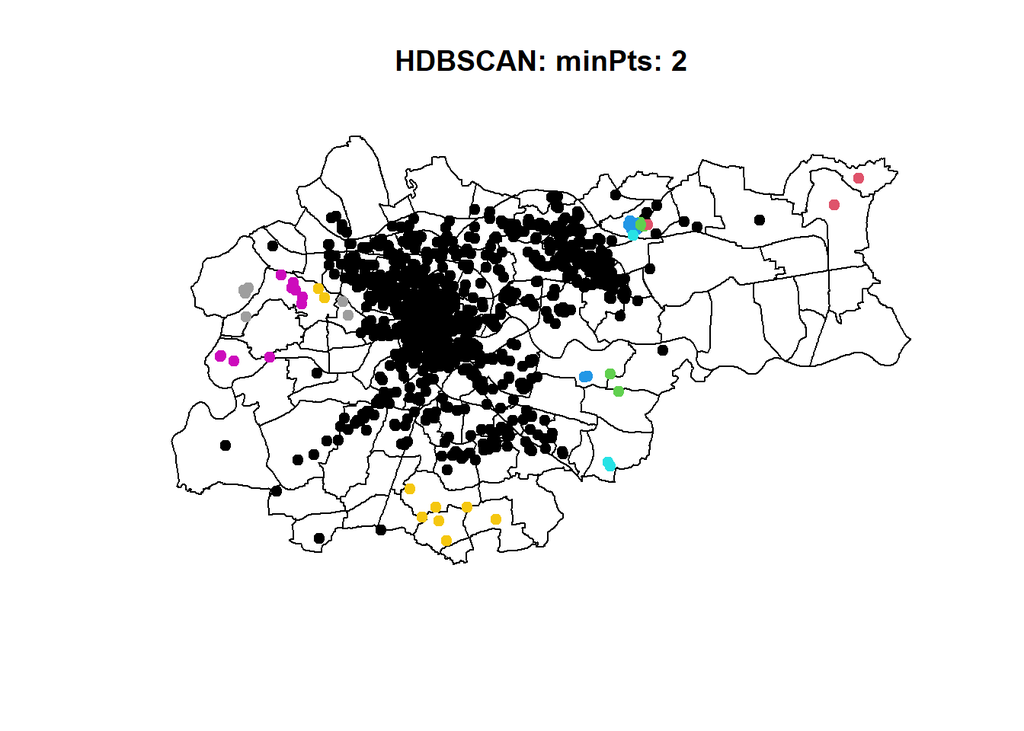

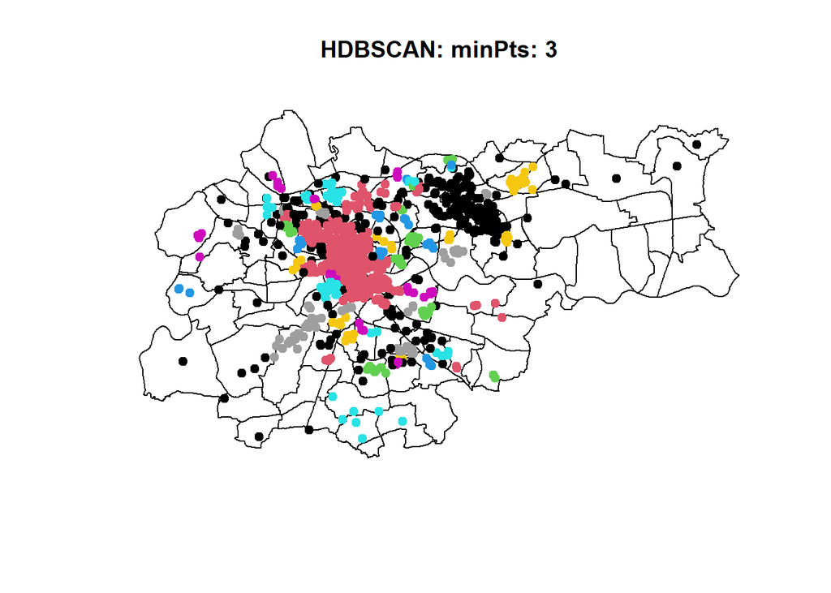

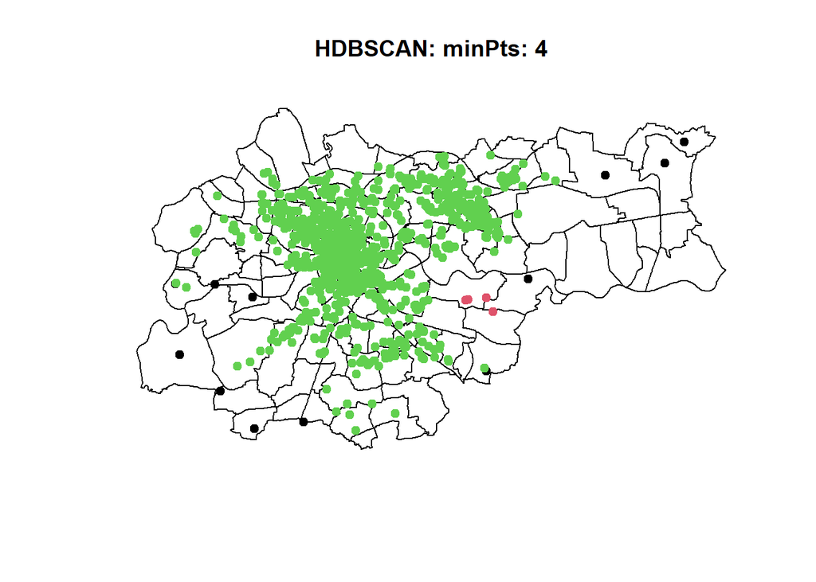

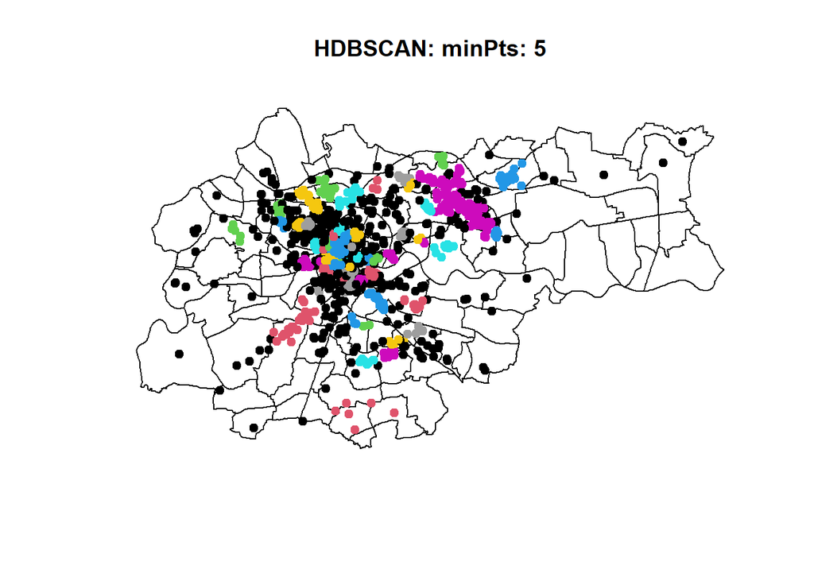

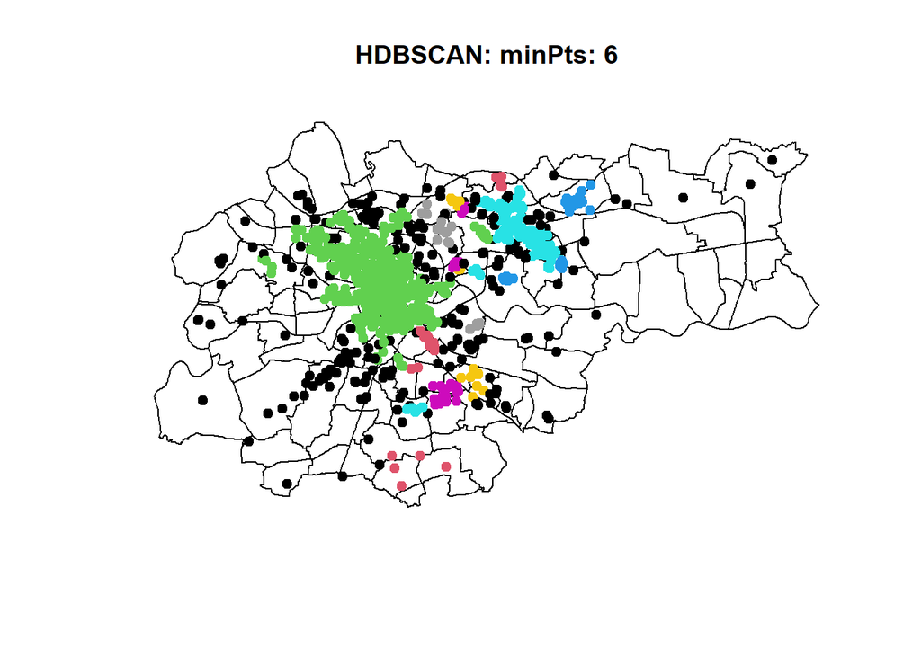

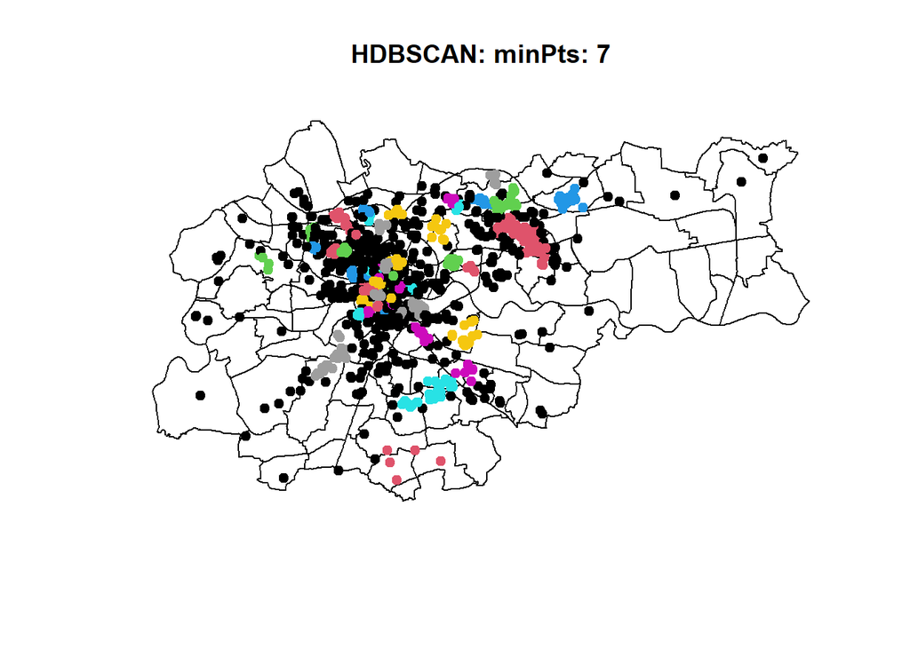

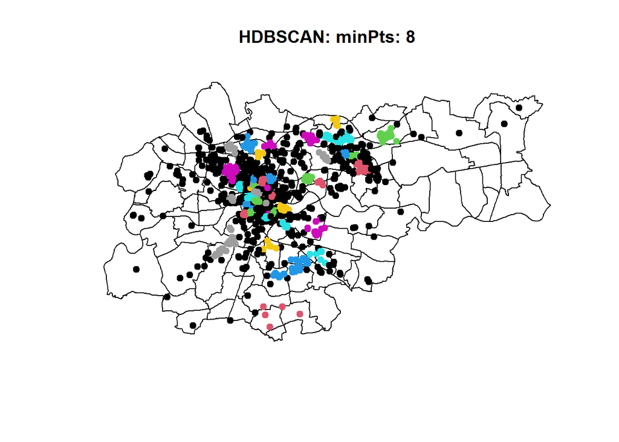

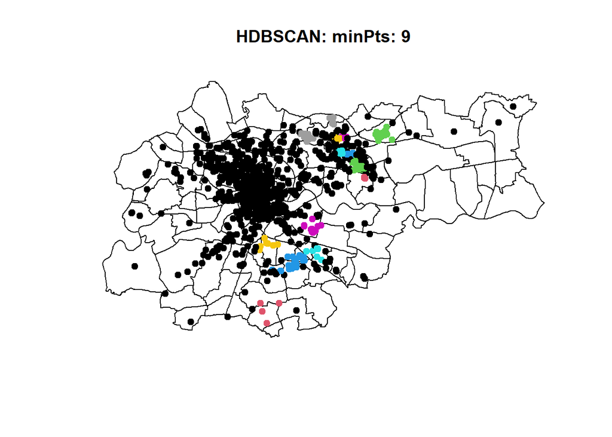

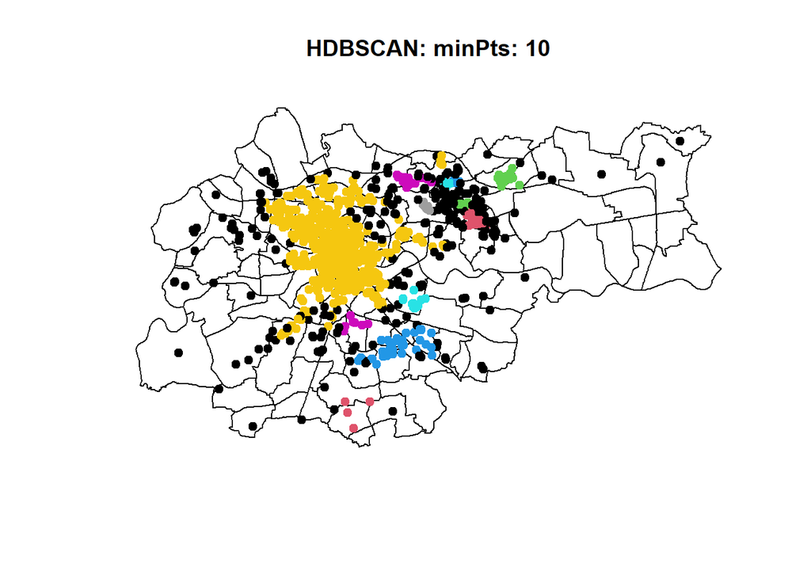

```r
min_pts_hdb = c( 2, 3, 4, 5, 6, 7, 8, 9, 10 )

for (p in min_pts_hdb) {
  hdbx = hdbscan( ramka, minPts = p )
  plot( osiedla$geometry)
  plot( punkty$geometry, add = TRUE, pch = 19, col = factor( hdbx$cluster ))
  title( main = glue( "HDBSCAN: minPts: {p}" ))
}
```

*Zalety i wady obu algorytmów*  
**DBSCAN**:  
Zalety:  
- Automatycznie identyfikuje szum  
- Nie trzeba ręcznie ustalać ilości klastrów  
Wady:  
- Nie radzi sobie zbyt dobrze z danymi o zmiennej gęstości  
- Trzeba ręcznie ustawiać eps  
***HDBSCAN**:  
Zalety:  
- Automatycznie ustawia eps  
- Lepiej identyfikuje szum  
Wady:  
- Bardzo wrażliwy na parametr minPts  
- Dużo bardziej złożony obliczeniowo